# QuantifiedMe

- **Created by:** Erik Bjäreholt ([GitHub](https://github.com/ErikBjare), [Twitter](https://twitter.com/ErikBjare), [LinkedIn](https://www.linkedin.com/in/erikbjareholt/))
- **Latest version:** https://erik.bjareholt.com/quantifiedme/Dashboard.html
- **Source:** https://github.com/ErikBjare/quantifiedme

QuantifiedMe is a collection of software tools for quantified self data. It is used to measure and manage behavior, productivity, health, habits, and life in general.

This public notebook is limited to time tracking data, with actual example data generated by aw-fakedata.

- Introduction
- Setup
  - Configuration
- Load data
  - Verify data
- Visualize
  - Today plot
  - Trends plot
  - Category sunburst
  - Fictional wage plot
  - Uncategorized
- Closing remarks

# Introduction

The phrase *"What gets measured gets managed"* is sometimes thrown around in professional contexts. While often just appreciated for its contextual face value, it's actually an important observation that today drives practically the entire world. Companies measure performance and financial results, engineering teams measure keep track of their tasks and resources, and scientists measure everything from health outcomes to the trajectory of interstellar objects that could threaten the planet.

Indeed, collecting and analysing data is the foundation for all of science, or as Lord Kelvin put it:

> *I often say that when you can measure what you are speaking about, and express it in numbers, you know something about it; but when you cannot express it in numbers, your knowledge is of a meagre and unsatisfactory kind; it may be the beginning of knowledge, but you have scarcely, in your thoughts, advanced to the stage of science, whatever the matter may be.*

> **– William Thomson** (Lord Kelvin), Lecture on "Electrical Units of Measurement" (1883)

**However**, although commonly practiced in professional contexts and having words thrown around like "data-driven", it's less common in our personal lives. We generally don't see problems in our personal lives as matters that could be solved through measuring and analysing. This is probably because we don't know which questions to ask, or that it seems too difficult to collect and analyze the data because we're unaware of the tools to get the job done, or simply because we compartmentalize the scientific method as a "work thing", or as something to be left to "real scientists".

So what if we had good open-source tools to easily ask questions and explore data about our personal lives? What if people shared the data with each other, and together worked on common personal problems (productivity, mental & physical health, work/life balance) in a truly scientific way? I think that seems worthy of exploring.

I've built some of those tools over the past years, among them the open-source time tracker [ActivityWatch](https://activitywatch.net/), and here's a little showcase of some of my work over that time. I've used a notebook like this one almost every week for almost a year to explore my behavior (many of the things didn't make the cut, sorry). It's been both fascinating and rich in insights about how I spend my time, and how I could do better in big and small ways. But the inquiry has just started, there's a lot more to come.

Now, dear reader, I've blabbered enough. Enjoy my work, I hope you find it of interest (and use!). Be sure to check out some of the links at the end for more stuff like this!

# Setup

First we do some imports, and set some variables used in the rest of the program.

```python
import random
import logging
import itertools
from datetime import datetime, time, date, timezone, timedelta
from pathlib import Path
from collections import Counter, defaultdict

import numpy as np
import pandas as pd
import matplotlib.pyplot as plt
import pytz
from IPython.utils import io
from IPython.display import display
from IPython.core.display import HTML

import aw_core
from aw_core.models import Event

import aw_research, aw_research.classify
from aw_transform import union_no_overlap

from quantifiedme.config import load_config
from quantifiedme.derived.screentime import load_screentime

# Use XKCD-style plots
# FIXME: Causes the day trend plots to take forever for some unknown reason
# matplotlib.pyplot.xkcd(scale=0.8, randomness=1)
```

## Configuration

**Modify these to your liking!**

```python
# Set this to your timezone
your_timezone = pytz.timezone('Europe/Stockholm')
tz_offset = your_timezone.utcoffset(datetime.now())

# Use personal data, not fake data
personal = False

# Set to True to limit amount of data loaded (useful when developing/debugging)
fast = True

# Can be set to True to run faster on consequtive runs, but will not reflect changes in data,
# so needs to be set to False every now and then to clear the cache.
cache = True

# Days of history to use
days_back = 30 if fast else 5*365
```

The below sets the window title to something more descriptive so that ActivityWatch can track that I'm working on this specific notebook (since the default isn't informative in JupyterLab).

```python
%%javascript
document.title='QuantifiedMe - Jupyter'
```

### Set current time

```python
# Now let's just set the current time and our query interval and we're ready to load data!
# If not running in personal mode, use a fixed datetime to make notebook reproducible
now = datetime.now(tz=timezone.utc) if personal else datetime(2021, 6, 9, tzinfo=timezone.utc)
day_offset = timedelta(hours=4)
today = datetime.combine(now.date(), time()).astimezone(timezone.utc) + day_offset
since = today - timedelta(days=days_back)

print(f"Today:  {today.date()}")
print(f"Start:  {since}")
print(f"End:    {now}")
```

```
Today:  2021-06-09
Start:  2021-05-10 04:00:00+00:00
End:    2021-06-09 00:00:00+00:00
```

# Load data

We will load data from all sources into the `events` variable.

Every consecutive source source will fill eventual gaps from previous sources (to prevent overlap), by using `union_no_overlap`.

```python
import pickle

cachefile = Path("events.pickle")
cachefile_fast = Path("events_fast.pickle")
load_pickled = False
if cache and load_pickled and cachefile.exists() and cachefile.stat().st_mtime > datetime.now().timestamp() - 60*60*24:
    print("Loading cached events")
    with cachefile.open('rb') as f:
        events = pickle.load(f)
else:
    # Uses my syncing testing instance to get multi-device data
    events = load_screentime(since, datasources=None, hostnames=None, personal=personal, cache=cache)
    # Save the events to a file so we can load them faster next time
    with cachefile.open('wb') as f:
        pickle.dump(events, f)
    # smaller version
    with cachefile_fast.open('wb') as f:
        pickle.dump(events[:1000], f)

print(f"First: {events[0].timestamp}")
print(f"Last:  {events[-1].timestamp}")
```

```
[WARNING] Found 137 events overlapping, totalling: 0:00:00.048547
[WARNING] Found 137 events overlapping, totalling: 0:00:00.048547
[WARNING] Found 137 events overlapping, totalling: 0:00:00.048547
[WARNING] Found 137 events overlapping, totalling: 0:00:00.048547
Query start: 2021-05-10 04:00:00+00:00
Events start: 2026-09-12 08:00:00+00:00
[WARNING] Found 137 events overlapping, totalling: 0:00:00.048547
First: 2026-09-12 08:00:00+00:00
Last:  2026-09-26 14:35:24.716000+00:00
```

# Inspect data

Now lets take a look at the data. Could help us discover potential bugs in loading code or issues with the data.

```
(0.0, 50.0)
```

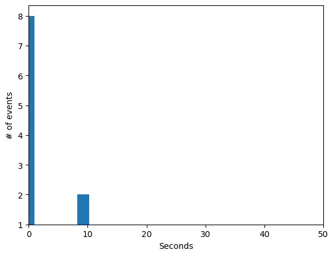

```python
# Inspect the distribution of event duration
fig, ax = plt.subplots()
xlim = 50
pd.Series([e.duration.total_seconds() for e in events if e.duration.total_seconds() <= xlim]).plot.hist(bins=10, bottom=1)
ax.set_xlabel('Seconds')
ax.set_ylabel('# of events')
ax.set_xlim(0, xlim)
#ax.set_yscale('log')

#df = pd.DataFrame(pd.Series([e.duration.total_seconds() for e in events]))
#df["dur"] = (df[0] // 10) * 10
#df["logdur"] = log((df[0] * 1).round())
#df[df["dur"] > 10]["dur"].plot.hist()
#df.groupby("dur").mean() * df.groupby("dur").count()
```

```python
# print the longest event
longest = sorted(events, key=lambda e: e.duration, reverse=True)[0]
print(f"Longest duration event was {longest.duration}")
```

```
Longest duration event was 2:59:48.587889
```

```
(0.0, 5.0)
```

[figure not shown]

```python
fig, ax = plt.subplots()
xlim = 5
pd.Series([e.duration.total_seconds() for e in events if e.duration.total_seconds() <= xlim]).plot.hist(bins=10, bottom=1)
ax.set_xlabel('Seconds')
ax.set_ylabel('# of events')
ax.set_xlim(0, xlim)
```

```
(0.0, 2.0)
```

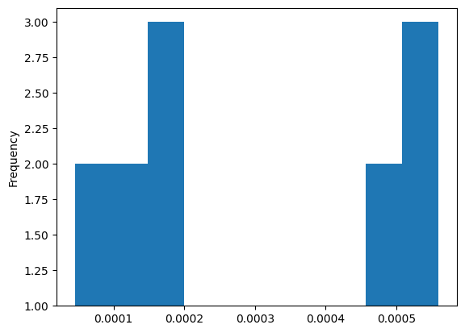

```python
xlim = 2
pd.Series([e.duration.total_seconds() for e in events if e.duration.total_seconds() <= xlim]).plot.hist(bins=10, bottom=1)
ax.set_xlabel('Seconds')
ax.set_ylabel('# of events')
ax.set_xlim(0, xlim)
```

```python
total_events = len(events)
short_thres = 5
short_events = len([e for e in events if e.duration.total_seconds() < short_thres])
print(f"# of total events:  {total_events}")
print(f"# of events <{short_thres}s:    {short_events} ({round(100 * short_events/total_events)}%)")
```

```
# of total events:  255
# of events <5s:    7 (3%)
```

## How much time is covered?

How much of the time in the range has been tracked?

```python
# TODO: Include sleep for improved coverage
tracking_cov = __builtins__.sum((e.duration for e in events), timedelta()) / (now - since)
print(f"Tracking coverage: {100 * tracking_cov:.3}%")
```

```
Tracking coverage: 11.5%
```

## Which devices are used the most?

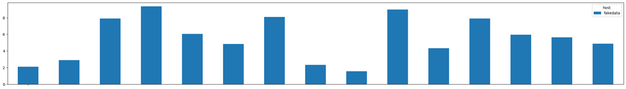

```python
time_by_source = defaultdict(float)
df_rows = []
for e in events:
    date = e.timestamp.date()
    source = e.data.get('$source', 'unknown')
    host = e.data.get('$hostname', 'unknown')
    duration = e.duration.total_seconds()
    time_by_source[host] += duration
    df_rows.append([date, source, host, duration])

def line_format(label):
    """
    Convert time label to the format of pandas line plot
    From: https://stackoverflow.com/a/53995225/965332
    """
    month = label.month_name()[:3]
    if month == 'Jan':
        month += f'\n{label.year}'
    return month


df = pd.DataFrame(df_rows, columns=["date", "source", "host", "duration"])
df = df.set_index(["date", "source", "host"])
df = df.groupby(level=[0,1,2]).sum()
df /= 60*60
df = df.unstack(level=2).fillna(0).reset_index().set_index('date')

df = df.drop(columns='source')
df = df.groupby(level=0).sum()

timeline = pd.to_datetime(pd.date_range(start=df.index[0], end=df.index[-1], freq='D'))
timeline_months = [date for date in timeline if date.day == 1]

# Add missing dates
df = df.reindex(pd.to_datetime(timeline), fill_value=0)

# Drop 'duration' level into individual hostname columns
df.columns = df.columns.droplevel(0)
assert len(df[df.index.duplicated()]) == 0

import matplotlib.dates as mdates
ax = df.plot.bar(stacked=True, figsize=(30, 4), ylim=(0, None), rot=0)

ax.xaxis.set_major_locator(mdates.MonthLocator())
ax.set_xticklabels(map(line_format, timeline_months));

#df
```

|  | source | duration | days |
| --- | --- | --- | --- |
| 0 | fakedata | 297705.495545 | 3.445665 |

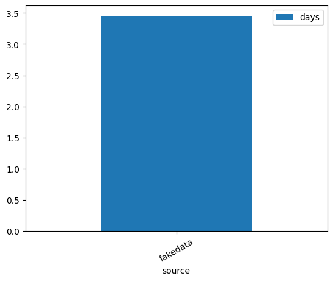

```python
df = pd.DataFrame({"source": time_by_source.keys(), "duration": time_by_source.values()})
df['days'] = df['duration'] / (60*60*24)
df.plot.bar(x='source', y='days', rot=30)
df
```

# Visualize

Here are some visualizations I've found useful to show how your activity today, over many days, and how much you've spent in each category.

TODO: Add calendar heatmap plot

## Today plot

Barchart of which hours you've been active today.

```python
from aw_research import split_event_on_hour, categorytime_per_day, categorytime_during_day, start_of_day, end_of_day

def plot_categorytime_during_day(events, category, color='teal'):
    df = categorytime_during_day(events, category, today)

    # FIXME: This will make the first and last hour to always be 0
    ix = pd.date_range(start=start_of_day(today) + day_offset - tz_offset,
                         end=start_of_day(today) + timedelta(hours=24) + day_offset - tz_offset,
                         freq='H')
    df = df.reindex(ix)
    df = df.sort_index().asfreq('H')

    fig = plt.figure(figsize=(18, 3))
    ax = df.plot(kind='bar', color=color, rot=60)
    ax.set_ylim(0, 1)
    plt.title(category or "All activity")

    def label_format_hour(label):
        """
        Convert time label to the format of pandas line plot
        Based on: https://stackoverflow.com/a/53995225/965332
        """
        label = label.replace(tzinfo=your_timezone)
        label = label + label.utcoffset()
        return f"{label.hour}:{str(label.minute).ljust(2, '0')}"  # if label.hour % 2 == 0 else ''

    ax.set_xticklabels([label_format_hour(dt) for dt in df.index])
    plt.tight_layout()
```

[figure not shown]

[figure not shown]

```python
plot_categorytime_during_day(events, "")
plot_categorytime_during_day(events, "Work", color='green')
```

# Timeline

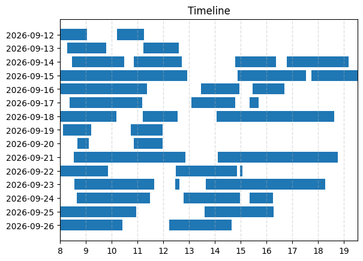

```python
from quantifiedme.timelineplot.plot import TimelineFigure
import matplotlib

fig = TimelineFigure(title="Timeline")

# TODO: plot timeline with bars colored according to:
#       - [ ] device used
#       - [x] category
#            - [ ] would be better with category colors configured

def dayevents_to_barsegments(events, colorkey='$hostname', cmap=matplotlib.colormaps['tab10']):
    # useful colorkey values: app, $hostname, $category_hierarchy
    groups = {}
    for e in events:
        if e.duration.total_seconds() < 5:
           continue
        t1 = e.timestamp.time()
        t2 = (e.timestamp + e.duration).time()
        if t1 > t2:
            # event crossing midnight, skip
            continue
        start = t1.hour * 60 * 60 + t1.minute * 60 + t1.second
        stop  = t2.hour * 60 * 60 + t2.minute * 60 + t2.second
        key   = e.data[colorkey]
        if key not in groups:
            groups[key] = len(groups)
        color = cmap(groups[key])
        yield ((start, stop), color, '')


# split events into days, days into bar segments
for date, dayevents in itertools.groupby(sorted(events, key=lambda e: e.timestamp), lambda e: e.timestamp.date()):
    dayevents = list(dayevents)
    second_of_day = e.timestamp.time()
    bar = [segment for segment in dayevents_to_barsegments(dayevents)]
    if bar:
        fig.add_bar(bar, title=str(date))

ticks = list(range(0, 24 * 60 * 60, 60 * 60))
labels = [str(t // (60*60)) for t in ticks]
fig.ax.set_xticks(ticks, labels)
fig.ax.grid(True, axis="x", linestyle='--', linewidth=1, zorder=-1000, alpha=0.4)
fig.plot()
# Needs extra work with matplotlib "artists" (never used before)
#fig.ax.legend()
```

## Trends plot

Useful to see how much you've engaged in a particular activity over time.

```python
def plot_category(cat, big=False, barcolor=(0.2, 0.4, 0.8, 0.5)):
    #aw_research.classify._plot_category_daily_trend(events, [cat])
    try:
        ts  = categorytime_per_day(events, cat)
    except Exception as e:
        print(f"Error for category '{cat}': {e}")
        return
    fig, ax = plt.subplots(figsize=(24, 5 if big else 3))
    ax.bar(ts.index, ts, label=f"{cat}: daily", color=barcolor)
    ax.plot(ts.index, ts.rolling(7, min_periods=4).mean(), label=f"7d SMA")
    ax.plot(ts.index, ts.rolling(30, min_periods=14).mean(), label=f"30d SMA")
    ax.plot(ts.index, ts.rolling(60, min_periods=30).mean(), label=f"60d SMA")
    plt.legend(loc='upper left')
    plt.title(cat)
    plt.xlim(pd.Timestamp(since), pd.Timestamp(now))
    plt.ylim(0)
    plt.grid(linestyle='--')
    plt.tight_layout()

color_prod = (0.1, 0.8, 0.1, 0.8)
color_unprod = (0.8, 0.1, 0.1, 0.8)
```

[figure not shown]

```python
# All logged activity
plot_category('', big=True)
```

```
Error for category 'QuantifiedMe': No events to calculate on
Error for category 'Thankful': No events to calculate on
Error for category 'Algobit': No events to calculate on
Error for category 'uniswap-python': No events to calculate on
```

[figure not shown]

[figure not shown]

[figure not shown]

```python
# Work-related
plot_category('Work', big=True, barcolor=color_prod)
plot_category('Programming')
plot_category('ActivityWatch')
plot_category('QuantifiedMe')
plot_category('Thankful')
plot_category('Algobit')
plot_category('uniswap-python')
```

```python
# School-related
plot_category('School')
plot_category('Self-directed')
plot_category('Maths')
```

```
Error for category 'School': No events to calculate on
Error for category 'Self-directed': No events to calculate on
Error for category 'Maths': No events to calculate on
```

```
Error for category 'Video': No events to calculate on
Error for category 'Games': No events to calculate on
```

[figure not shown]

[figure not shown]

[figure not shown]

```python
# Entertainment
plot_category('Media', big=True, barcolor=color_unprod)
plot_category('Social Media')
plot_category('Video')
plot_category('Music')
plot_category('Games')
```

[figure not shown]

```python
# All uncategorized time
plot_category('Uncategorized')
```

## Category sunburst

Uses the category hierarchy to create an overview of how time has been spent during a given period.

```python
events_today = [e for e in events if today < e.timestamp]
```

```python
def plot_sunburst(events):
    plt.figure(figsize=(6, 6))
    aw_research.classify._plot_category_hierarchy_sunburst(events)
    display(HTML(f"<b>Total duration: {__builtin__.sum((e.duration for e in events), timedelta(0))}</b>"))
```

```python
plot_sunburst(events_today)
```

[output not shown]

**Total duration: 3 days, 10:41:45.495545**

```python
plot_sunburst([e for e in events if today - timedelta(days=30) < e.timestamp])
```

[output not shown]

**Total duration: 3 days, 10:41:45.495545**

```python
plot_sunburst(events)
```

[output not shown]

**Total duration: 3 days, 10:41:45.495545**

## Fictional wage plot

Prioritizing things in life can be hard, and it's not uncommon to want to maximize how much you earn. But how much is working on project X actually worth to you in monetary terms? What about project Y?

By assigning hourly wages to different categories we can plot which activities we've earned the most (fictional) money from! This can help you identify how much you expect to have earned both from different activities and in total.

```
Exception for category QuantifiedMe: No events to calculate on
Exception for category Thankful: No events to calculate on
Exception for category School: No events to calculate on
Exception for category Algobit: No events to calculate on
Exception for category Finance: No events to calculate on
```

[figure not shown]

```python
# NOTE: Setting a rate for a subcategory will add to the rate for the parent category, if any
category_wages = {
    "Work": 30,  # Base rate
    "ActivityWatch": 15,  # In addition to the base rate
    "QuantifiedMe": 40,   # Self-analyzing my behavior probably has high returns
    "Thankful": 40,
    "School": 60,
    "Algobit": 100,
    "Finance": 100,
}

def plot_wages(events, category_wages):
    fig, ax1 = plt.subplots()

    df = pd.DataFrame()
    for cat, wage in category_wages.items():
        try:
            df[cat] = wage * categorytime_per_day(events, cat)
        except Exception as e:
            print(f"Exception for category {cat}: {e}")
    df.plot.area(label='total', stacked=True, figsize=(16, 4), ax=ax1, legend=False)
    ax1.set_ylabel("Daily wage ($)")
    ax1.legend(loc=1)

    #ax2 = ax1.twinx()
    #df.sum(axis=1).rolling(7).mean().plot(label='Total 7d SMA', legend=False, ax=ax2)
    df.sum(axis=1).rolling(30).mean().plot(label='Total 30d SMA', legend=False, ax=ax1)
    #ax2.set_ylabel("Daily wage ($)")
    #ax2.legend(loc=2)
    plt.xlim(pd.Timestamp(since), pd.Timestamp(now))
    plt.grid(linestyle='-.')
    plt.tight_layout()

plot_wages(events, category_wages)
```

# Category checks

Lets dig into some categories to see what they contain.

## Uncategorized

To check for events we could classify better.

```python
def time_per_keyval(events, key):
    vals = defaultdict(lambda: timedelta(0))
    for e in events:
        if key in e.data:
            vals[e.data[key]] += e.duration
        else:
            vals[f'key {key} did not exist'] += e.duration
    return vals

def print_time_per_keyval(events, key, limit=20, sortby='duration'):
    from tabulate import tabulate
    if sortby == 'duration':
        l = sorted([(v, k) for k, v in time_per_keyval(events, key).items()], reverse=True)
    elif sortby == 'key':
        l = sorted([(k, v) for k, v in time_per_keyval(events, key).items()], reverse=True)
    else:
        raise ValueError(f'invalid option for sortby, was "{sortby}"')
    print(tabulate(l[:limit], headers=['time', 'val']))

events_uncategorized = [e for e in events if 'Uncategorized' in e.data['$tags']]
print_time_per_keyval(events_uncategorized, 'title', limit=10)
```

```
time            val
--------------  --------------------------------------
7:03:55.346588  Minecraft
5:01:56.559342  Unknown site
3:18:56.371142  Zoom Meeting
2:37:25.716515  Stack Overflow - stackoverflow.com/
2:30:50.575335  Gmail - mail.google.com/
0:29:24.829413  Google Calendar - calendar.google.com/
```

```python
events_uncategorized_today = [e for e in events_uncategorized if e.timestamp > today]
print_time_per_keyval(events_uncategorized_today, 'title')
```

```
time            val
--------------  --------------------------------------
7:03:55.346588  Minecraft
5:01:56.559342  Unknown site
3:18:56.371142  Zoom Meeting
2:37:25.716515  Stack Overflow - stackoverflow.com/
2:30:50.575335  Gmail - mail.google.com/
0:29:24.829413  Google Calendar - calendar.google.com/
```

## Underspecified categories

Lets dig into a category with many children to see if some events can be classified better.

```python
events_programming = [e for e in events if 'Work -> Programming' == e.data['$category_hierarchy']]
print_time_per_keyval(events_programming, 'title')
```

```
time    val
------  -----
```

```python
#print_time_per_keyval(events, "$category_hierarchy", limit=100, sortby='key')
#tabulate(set(e.data["$category_hierarchy"] for e in events))
```

```python
print_time_per_keyval(events, '$source')
```

```
time                     val
-----------------------  -------------
3 days, 10:41:45.495545  activitywatch
```

## Category tree

Build a tree structure to compute aggregate times.

```python
from aw_research.tree import Node

def build_tree(data: dict):
    root = Node('root', timedelta())
    for k, v in sorted(data.items()):
        hier = k.split(" -> ")
        parent = root
        # Get (or create) parent
        for level in hier[:-1]:
            if not level in parent:
                # Create parent node
                parent += Node(level, timedelta())
            parent = parent[level]
        # Create child node
        level = hier[-1]
        if level not in parent:
            parent += Node(level, v)
        else:
            print("Unexpected!")
    return root

root = build_tree(time_per_keyval(events, '$category_hierarchy'))
print(root.print())
```

```
root:                 3 days, 10:41:45.495545  (0:00:00)
    Work:             1 day, 20:11:31.223818  (0:00:00)
        Programming:  1 day, 20:11:31.223818  (0:00:00)
            ActivityWatch:  1 day, 20:11:31.223818
    Uncategorized:    21:02:29.398335
    Social Media:     9:57:40.977489  (0:00:00)
        Reddit:       5:17:34.044530
        Twitter:      3:15:28.351646
        Facebook:     1:24:38.581313
    Media:            7:30:03.895903  (0:00:00)
        YouTube:      6:09:50.916270
        Music:        1:20:12.979633
```

# Closing remarks

That's the end of the notebook, thank you for checking it out!

I hope you'll upvote and/or comment wherever you saw it to help it get seen!

### Share & donate!

**Did you like it? Consider supporting us so we can keep building!**

- TODO: Add link/image/button to Patreon
- Like ActivityWatch on AlternativeTo! (TODO: ...and ProductHunt)
- Post about it on Twitter!

### Run it yourself!

You can run this notebook with your own data, it's a lot more fun!

Download and install [ActivityWatch](https://activitywatch.net), then check out the [quantifiedme repo](https://github.com/ErikBjare/quantifiedme) for usage instructions.

- TODO: Actually add details for how to run it in the README

### Other interesting links

- [Memento Labs](https://mementolabs.io/), a platform for self-study using quantified self data.

### Thanks to

- [Johan Bjäreholt](https://github.com/johan-bjareholt), my brother, for his amazing contributions, and for working on ActivityWatch with me for so long. **This wouldn't be possible without him.**
- All the other contributors, whose [stats are listed here](http://activitywatch.net/contributors/).
- Our Patrons/backers/supporters, your financial contribution means a lot!
- [@karpathy](https://twitter.com/karpathy) for creating ulogme, a spiritual ancestor of ActivityWatch
- Our users, you motivate us to keep working!

## TODO: Post to

- Reddit
- Hacker News
- Twitter
- ActivityWatch Forum (under the 'Projects' category)